# Lab 2: Modelling (practice)

Author

Ashley Walsh

Published

August 3, 2026

## Setup

```python
import numpy as np
import pandas as pd
import matplotlib.pyplot as plt
```

# Part 1: The Python you need for a model

## Variables and printing

```python
# variables of different types

concentration = 100.0     # a floating-point number
day = 0                   # an integer
site = "Waikato River"    # a string
is_tidal = True           # a boolean

print(concentration)
print(day, site, is_tidal)
```

```
100.0
0 Waikato River True
```

```python
# f-strings for formatted printing

day = 5
concentration = 47.6183

print(f"Day {day}: concentration = {concentration} mg/L")       # no rounding
print(f"Day {day}: concentration = {concentration:.2f} mg/L")   # round to 2 decimals
print(f"Day {day}: concentration = {concentration:.0f} mg/L")   # round to whole
```

```
Day 5: concentration = 47.6183 mg/L
Day 5: concentration = 47.62 mg/L
Day 5: concentration = 48 mg/L
```

## Numbers, arithmetic, and rounding

```python
a = 7
b = 2

print(a + b, a - b, a * b, a / b, a // b, a ** b)
#   sum, diff, product, division, floor-div, power
```

```
9 5 14 3.5 3 49
```

```python
# common rounding functions
x = 3.14159

print(round(x, 2))        # 3.14   — built-in rounding
print(round(x))           # 3      — no argument = to integer
print(int(x))             # 3      — truncates towards zero

round(3.5) # python uses "bankers rounding" rounds to nearest even number
round(2.5)
```

```
3.14
3
3
```

```
2
```

## Lists

A list holds several values in order. You will use lists to store time series before we switch to NumPy.

```python
values = [100.0, 95.0, 90.25, 85.7]

print(values)
print(values[0])       # first item (index 0)
print(values[1])       # second item
print(values[-1])      # last item
print(values[-2])      # second last

print(len(values))     # how many items in the list
```

```
[100.0, 95.0, 90.25, 85.7]
100.0
95.0
85.7
90.25
4
```

Slicing — grab a range with [start:stop] (stop is exclusive):

```python
values = [10, 20, 30, 40, 50, 60, 70, 80]

print(values[0:3])     # [10, 20, 30]  first three
print(values[2:5])     # [30, 40, 50]  middle
print(values[:4])      # [10, 20, 30, 40]  from the start
print(values[4:])      # [50, 60, 70, 80]  to the end
print(values[-3:])     # [60, 70, 80]  last three
```

```
[10, 20, 30]
[30, 40, 50]
[10, 20, 30, 40]
[50, 60, 70, 80]
[60, 70, 80]
```

Add to a list with `append()`:

```python
history = [100.0]
history.append(95.0)
history.append(90.25)

print(history)
print(f"Started at {history[0]}, ended at {history[-1]}") # gives the first and last values
```

```
[100.0, 95.0, 90.25]
Started at 100.0, ended at 90.25
```

## ‘for’ loops

A loop repeats an action. This is the engine of every numerical model in this course.

The simplest form loops over a range of integers:

```python
for step in range(5):       # goes from 0 to 4 (5 steps)
    print(f"Step {step}")
```

```
Step 0
Step 1
Step 2
Step 3
Step 4
```

You can also loop over the items in a list — very useful when you have a set of parameter values or site names:

```python
for k in [0.02, 0.05, 0.10, 0.20]:
    print(f"Decay rate k = {k}")
```

```
Decay rate k = 0.02
Decay rate k = 0.05
Decay rate k = 0.1
Decay rate k = 0.2
```

```python
sites = ["Waikato", "Waipa", "Piako"]
for name in sites:
    print(f"Loading data for {name}")
```

```
Loading data for Waikato
Loading data for Waipa
Loading data for Piako
```

`range(start, stop, step)` also takes a step size — handy for skipping every second value:

```python
for day in range(0, 20, 5):     # 0, 5, 10, 15
    print(f"Day {day}: take a sample")
```

```
Day 0: take a sample
Day 5: take a sample
Day 10: take a sample
Day 15: take a sample
```

Sum values as you loop. This pattern appears constantly in modelling:

```python
total = 0
for value in [3.2, 4.1, 2.8, 5.5]:
    total = total + value
print(f"Sum = {total}")
print(f"Mean = {total / 4}")
```

```
Sum = 15.6
Mean = 3.9
```

Here is a loop that updates a state variable each step. Read this cell carefully — every model in this part looks like it.

The pattern is:

A **state variable** (concentration) A **rule** for its rate of change (- decay_rate * concentration) A **loop** over time A **history** list so we can plot it later

```python
concentration = 100.0
decay_rate = 0.05
dt = 1.0
history = [concentration]     # store the starting value

for step in range(10):
    concentration = concentration - decay_rate * concentration * dt
    history.append(concentration)

print(history)
```

```
[100.0, 95.0, 90.25, 85.7375, 81.450625, 77.37809375, 73.5091890625, 69.833729609375, 66.34204312890625, 63.02494097246094, 59.87369392383789]
```

## Rounding a whole list

Printing 4 decimal places for every step is noisy. Two common ways to clean it up.

Both do the same thing. Start with option 2 until list comprehensions feel natural, then use option 1.

```python
# 1. A list comprehension (concise)
rounded = [round(c, 2) for c in history]
print(rounded)

# 2. A plain for loop (verbose but clearer for beginners)
rounded = []
for c in history:
    rounded.append(round(c, 2))

print(rounded)
```

```
[100.0, 95.0, 90.25, 85.74, 81.45, 77.38, 73.51, 69.83, 66.34, 63.02, 59.87]
[100.0, 95.0, 90.25, 85.74, 81.45, 77.38, 73.51, 69.83, 66.34, 63.02, 59.87]
```

## Functions

A function packages reusable logic under a name. Once you have written it, you can call it as many times as you like without repeating the code.

**How to build a function** Every function you write has the same five parts. Read this diagram before the examples:

```python
def celsius_to_kelvin(t_c):   # 1. def   2. name   3. (inputs):
    result = t_c + 273.15     # 4. the body — indented, does the work
    return result             # 5. return — hands a value back
```

1. `def` — the keyword that tells Python “I am defining a function”.
2. A **name** — you choose it. Use lowercase words joined by underscores (`celsius_to_kelvin`, `decay_step`). The name should say what the function does.
3. **Inputs in parentheses, then a colon** — the names inside () are the values the function needs. These are called parameters. End the line with :.
4. The **body** — one or more lines, each **indented** (4 spaces). This is the work the function does.
5. `return` — hands one value back to whoever called the function. Without return, the function does its work but gives you nothing back.

**Important**

The indentation is not decoration — it is how Python knows which lines belong to the function. Every line of the body must be indented by the same amount. VS Code adds the 4 spaces for you when you press Enter after the :.

**Defining a function does not run it.** You *call* it separately, by writing its name followed by values in parentheses:

```python
def celsius_to_kelvin(t_c):
    result = t_c + 273.15
    return result

# nothing has printed yet — we only defined the function above.
# now we CALL it three times:
print(celsius_to_kelvin(0))
print(celsius_to_kelvin(25))
print(celsius_to_kelvin(-40))
```

```
273.15
298.15
233.14999999999998
```

The value you pass in (`0, 25, -40`) lands in the parameter `t_c` for the duration of that call. Once you understand this one idea — values go in, a value comes back — you understand functions.

You do not need a separate `result` variable; you can return the expression directly:

```python
def celsius_to_kelvin(t_c):
    return t_c + 273.15

print(celsius_to_kelvin(100))
```

```
373.15
```

A fuction can take several inputs and return one number:

```python
def rectangle_area(length, width):
    return length * width

print(rectangle_area(5, 3))
print(rectangle_area(10, 2.5))
```

```
15
25.0
```

You can use a function *inside a loop* - the function handles one step, the loop handles the repetition.

```python
def decay_step(c, rate, dt):
    """Return the new concentration after one time step."""
    return c - rate * c * dt

c = 100.0
for _ in range(3):
    c = decay_step(c, 0.05, 1.0)
    print(f"{c:.4f}")
```

```
95.0000
90.2500
85.7375
```

the `for _ in range(3)` is a common idiom when you do not need the loop variable. The `_` is a placeholder that says “I don’t care about this value” & you just want to repeat the block 3 times.

```python
def discount_price(original, percent):
    """Return the price after a discount of percent% is applied."""
    return original * (1 - percent / 100)

original = 50.0
for _ in range(3):
    original = discount_price(original, 10)
    print(f"Price after 10% discount: ${original:.2f}")
```

```
Price after 10% discount: $45.00
Price after 10% discount: $40.50
Price after 10% discount: $36.45
```

## Conditionals

A conditional lets your program make a choice. The simplest form is `if`:

```python
temperature = 32

if temperature > 30:
    print("It's hot!")
```

```
It's hot!
```

Add `else` to handle the other case:

```python
temperature = 12

if temperature > 30:
    print("It's hot!")
else:
    print("It's not hot.")
```

```
It's not hot.
```

Use `elif` (short for “else if”) to check several conditions in order:

```python
concentration = 5.0

if concentration > 10:
    print("High concentration")
elif concentration > 5:
    print("Moderate concentration")
else:
    print("Low concentration")
```

```
Low concentration
```

```python
readings = [4.2, 12.5, 8.1, 47.3, 55.0, 3.8]

for value in readings:
    if value > 10:
        label = "safe"
    elif value < 50:
        label = "elevated"
    else:
        label = "danger"
    print(f"{value:>5.1f} mg/L -> {label}") # note: The > after : in {value:>5.1f} right-aligns the number in a 5-character column so the table looks neat.
```

```
  4.2 mg/L -> elevated
 12.5 mg/L -> safe
  8.1 mg/L -> elevated
 47.3 mg/L -> safe
 55.0 mg/L -> safe
  3.8 mg/L -> elevated
```

## NumPy arrays

Lists work for small models, but NumPy arrays are faster and let you do maths on whole sequences at once. We will use them for the rest of the course.

```python
import numpy as np

# arrange: like range, but for floats
time = np.arange(0, 10, 0.5)   # from 0 to 10 (exclusive), step 0.5
print(time)
print(time[0:5]) # slicing works the same as for lists

# linsapce: N points evenly spcaed from A to B (inclusive of both)
x = np.linspace(0, 2 * np.pi, 20)  # 20 points from 0 to 2π
print(f"x has {len(x)} points, first three: {x[:3]}")
```

```
[0.  0.5 1.  1.5 2.  2.5 3.  3.5 4.  4.5 5.  5.5 6.  6.5 7.  7.5 8.  8.5
 9.  9.5]
[0.  0.5 1.  1.5 2. ]
x has 20 points, first three: [0.         0.33069396 0.66138793]
```

Maths on a whole array at once:

```python
time = np.arange(0, 10, 1.0) # note: step is the increment, not the number of points, before it reaches the stop value

concentration = 100.0 * np.exp(-0.05 * time) # exact solution of dC/dt = -kC
print(np.round(concentration, 2))  # round to 2 decimals
```

```
[100.    95.12  90.48  86.07  81.87  77.88  74.08  70.47  67.03  63.76]
```

Notice `np.round` - same idea as the built-in `round`, but works on arrays.

Some NumPy operations you will use in labs:

```python
values = np.array([10, 20, 30, 40, 50])

print(values.mean())   # arithmetic mean
print(values.min(), values.max())  # min and max
print(values.sum())    # sum of all values
print(np.median(values))  # median
print(values[-3:].mean())  # mean of last three values - very common in time series analysis
```

```
30.0
10 50
150
30.0
40.0
```

## Plotting with matplotlib

Every models needs a plot to check whether the output makes sense. We use a library called matplotlib. You import it once at the top of your file:

```python
import matplotlib.pyplot as plt
```

`plt` is the standard abbreviation for `matplotlib.pyplot` so you don’t have to type the full thing each time. You can use it to create a figure, add axes, and plot lines.

#### The simplest possible plot

Give matplotlab two lists (or arrays) of the same length: x values and y values. It will draw a line connecting the points.

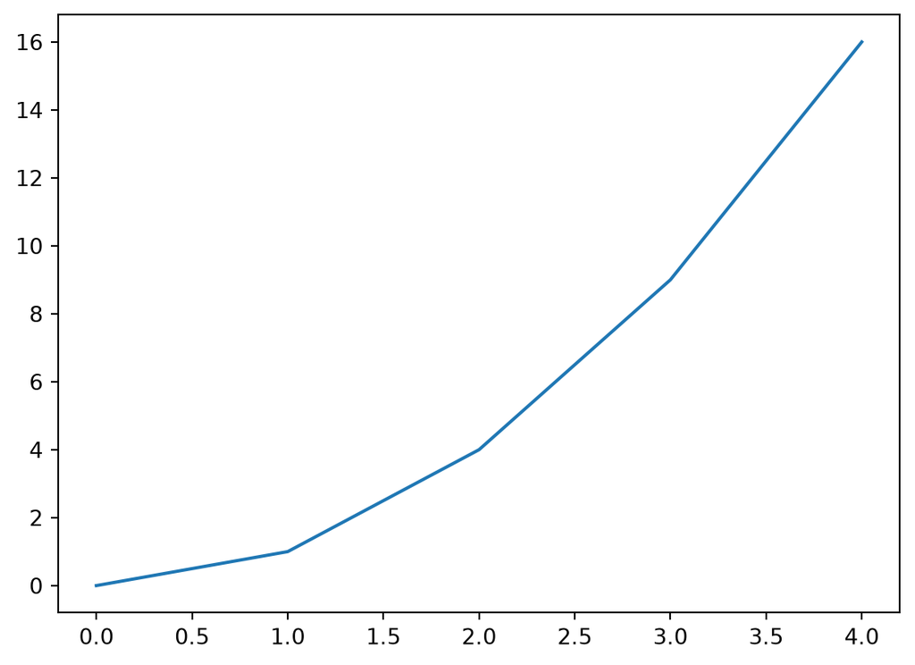

```python
x = [0, 1, 2, 3, 4]
y = [0, 1, 4, 9, 16]

plt.plot(x, y)
plt.show()
```

This is a real plot in two lines. `plt.plot(x, y)` draws the line, and `plt.show()` displays it. The first point is (0, 0), the second (1, 1), the third (2, 4), and so on — x and y are read in pairs.

#### Always label your axes

A plot with no labels is almost useless — nobody (including you, next week) knows what it shows. Add a label to each axis and a title:

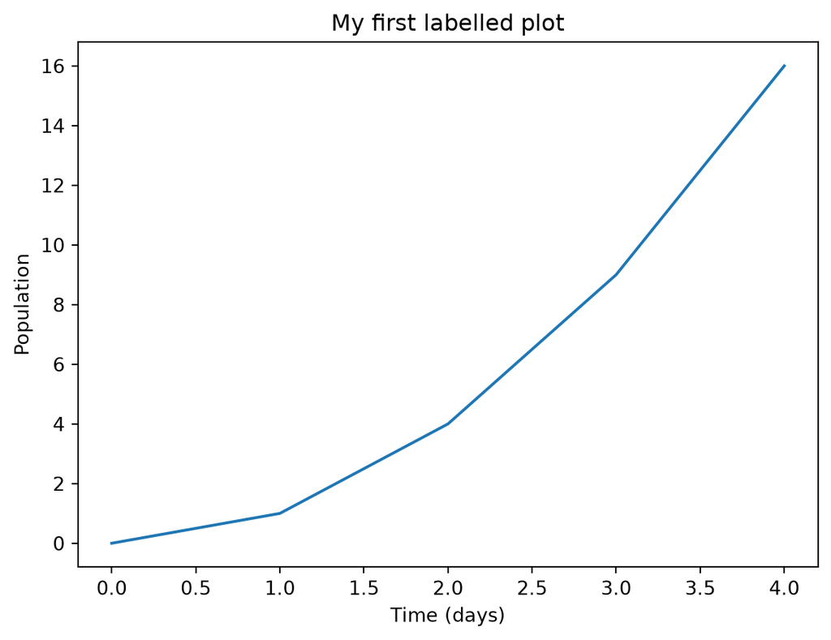

```python
x = [0, 1, 2, 3, 4]
y = [0, 1, 4, 9, 16]

plt.plot(x, y)
plt.xlabel("Time (days)")
plt.ylabel("Population")
plt.title("My first labelled plot")
plt.show()
```

Three commands, three labels. **Every plot you submit in this course must have these three.** Marks are lost for unlabelled figures.

#### Markers, colours, and styles

By default `plot` draws a plain line. You can show the individual data points and change the colour with a short format string.

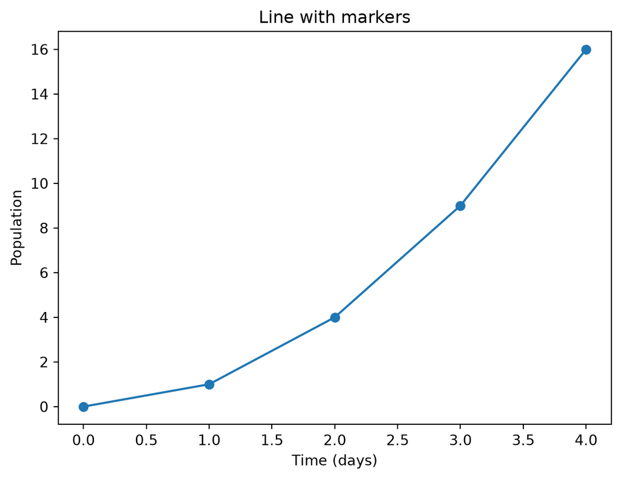

```python
x = [0, 1, 2, 3, 4]
y = [0, 1, 4, 9, 16]

plt.plot(x, y, "o-")      # "o" = circle markers, "-" = solid line
plt.xlabel("Time (days)")
plt.ylabel("Population")
plt.title("Line with markers")
plt.show()
```

A few format strings to try: `"o-"` (circles + line), `"s--"` (squares + dashed line), `"r-"` (red line), `"g^"` (green triangles, no line).

#### The style we use from here on

You will see two ways to make plots in tutorials online. The one above (`plt.plot`, `plt.xlabel`, …) is fine for a quick look. For everything in this course we use the slightly more explicit `fig`, `ax` style, because it scales up cleanly to figures with several panels:

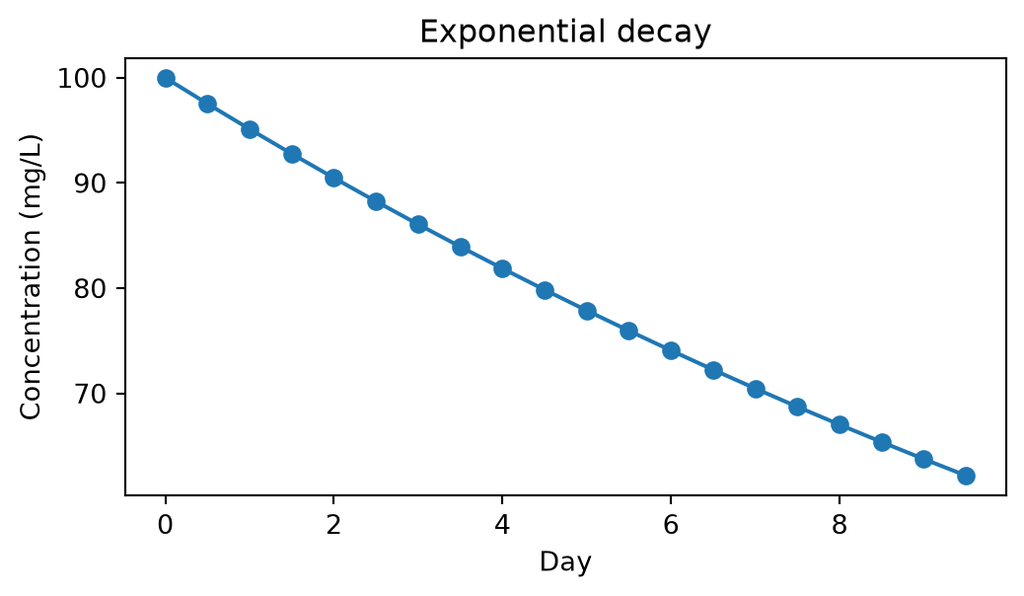

```python
time = np.arange(0, 10, 0.5)
concentration = 100.0 * np.exp(-0.05 * time)

fig, ax = plt.subplots(figsize=(6, 3))     # make a figure and one set of axes
ax.plot(time, concentration, marker="o", linestyle="-")
ax.set_xlabel("Day")
ax.set_ylabel("Concentration (mg/L)")
ax.set_title("Exponential decay")
plt.show()
```

It looks longer, but it is the same idea. The differences:

- `fig, ax = plt.subplots(figsize=(6, 3))` creates the figure and hands you an ax object (the plotting area). `figsize` is the width and height in inches.
- You call methods on ax: `ax.plot`, `ax.set_xlabel` (note: `set_xlabel`, not `xlabel`).

#### Several lines on one figure

The plot you will make most often in this course overlays scenarios — here, three decay rates. Call `ax.plot` once per line, give each a `label`, and finish with `ax.legend()` so the reader knows which line is which:

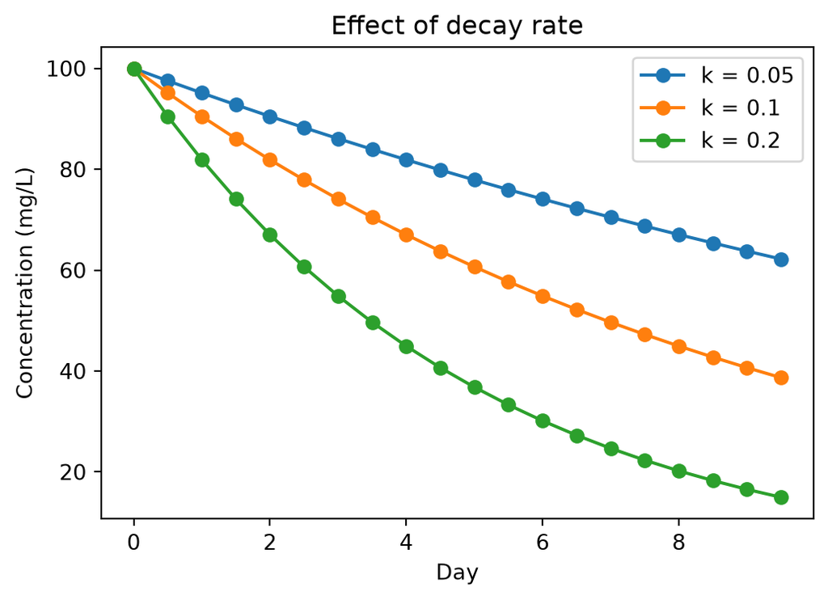

```python
time = np.arange(0, 10, 0.5)

fig, ax = plt.subplots(figsize=(6, 4))

for k in [0.05, 0.1, 0.2]:
    c = 100.0 * np.exp(-k * time)
    ax.plot(time, c, marker="o", label=f"k = {k}")

ax.set_xlabel("Day")
ax.set_ylabel("Concentration (mg/L)")
ax.set_title("Effect of decay rate")
ax.legend()
plt.show()
```

The `label=f"k = {k}"` is what fills in the legend box. Without `ax.legend()` the labels are stored but not shown.`

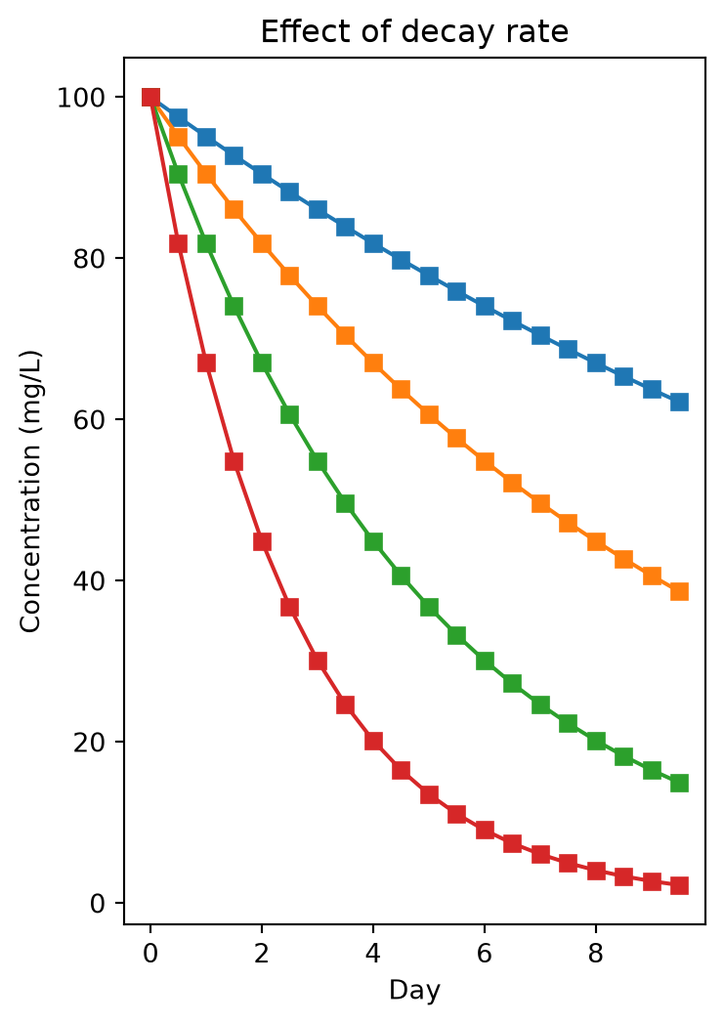

```python
# Add a fourth decay rate (say k = 0.4). Change the marker to "s" (a square). Change the figure size to (4, 6) (tall and narrow). Remove the ax.legend() line and see what disappears.

time = np.arange(0, 10, 0.5)

fig, ax = plt.subplots(figsize=(4, 6))

for k in [0.05, 0.1, 0.2, 0.4]:
    c = 100.0 * np.exp(-k * time)
    ax.plot(time, c, marker="s", label=f"k = {k}")

ax.set_xlabel("Day")
ax.set_ylabel("Concentration (mg/L)")
ax.set_title("Effect of decay rate")
plt.show()
```

# Part 2: Frome a differential equation to code

The lecture defined a numerical model as one that solves a differential equation by discretising it — replacing an infinitesimal rate of change with a finite difference over a small step.

In words: the new value equals the old value plus the rate times the time step. In code:

```python
a = 2.0      # constant rate of change
u = 0.0       # initial condition
dt = 0.5      # time step
steps = 20

history = [u]
for _ in range(steps):
    u = u + a * dt        # forward difference: u_f = u_i + a*dt
    history.append(u)

time = np.arange(len(history)) * dt

print(f"Started at {history[0]}, ended at {history[-1]}")
print(f"Length of history: {len(history)}")
print(f"First six values: {[round(h, 2) for h in history[:6]]}")
```

```
Started at 0.0, ended at 20.0
Length of history: 21
First six values: [0.0, 1.0, 2.0, 3.0, 4.0, 5.0]
```

This scheme — take the current value and add the rate times the step — is called **forward differencing**, or the **Euler method**. Every model in Part 2 uses it.

# Part 3: Two techniques from the lecture

## Forward and centre differencing

Forward differencing is good for **time-stepping**, because at time (i) we only know the past. Centre differencing is more accurate and is good for **spatial gradients**, because at cell (i) we know both neighbours.

We can see the accuracy difference on a known function whose derivative is exact — sin(x), whose derivative is cos(x).

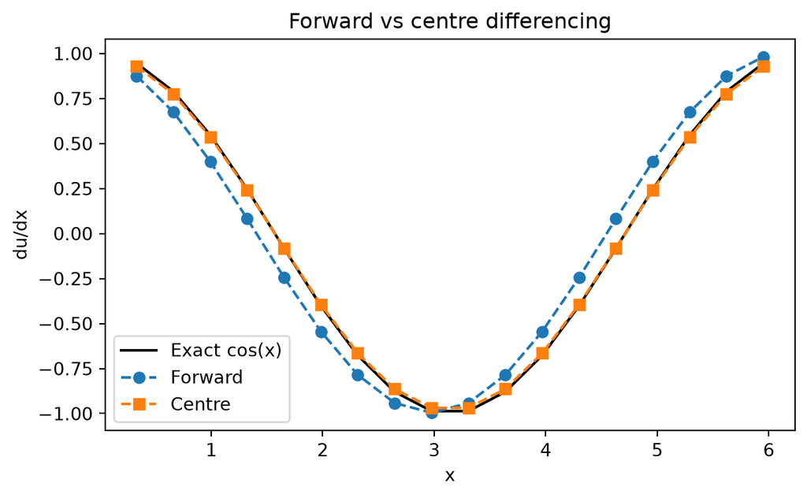

```python
x = np.linspace(0, 2 * np.pi, 20)
dx = x[1] - x[0]              # spacing between grid points
u = np.sin(x)
exact = np.cos(x)             # the true derivative

# np.roll shifts an array by one step
forward = (np.roll(u, -1) - u) / dx
centre = (np.roll(u, -1) - np.roll(u, 1)) / (2 * dx)

fig, ax = plt.subplots(figsize=(7, 4))
ax.plot(x[1:-1], exact[1:-1], "k-", label="Exact cos(x)")
ax.plot(x[1:-1], forward[1:-1], "o--", label="Forward")
ax.plot(x[1:-1], centre[1:-1], "s--", label="Centre")
ax.set_xlabel("x")
ax.set_ylabel("du/dx")
ax.set_title("Forward vs centre differencing")
ax.legend()
plt.show()
```

The centre scheme tracks the true derivative more closely. This is why models typically use **centre differencing in space and forward differencing in time.**

## Stability and step size

Discretisation is an approximation. A step that is too large can make a model inaccurate or unstable.

Consider **tracer decay** (a real example from the lecture - you can see this on the GitHub repo for the class). Because we know the exact answer, we can see what happens when the time step is too large.

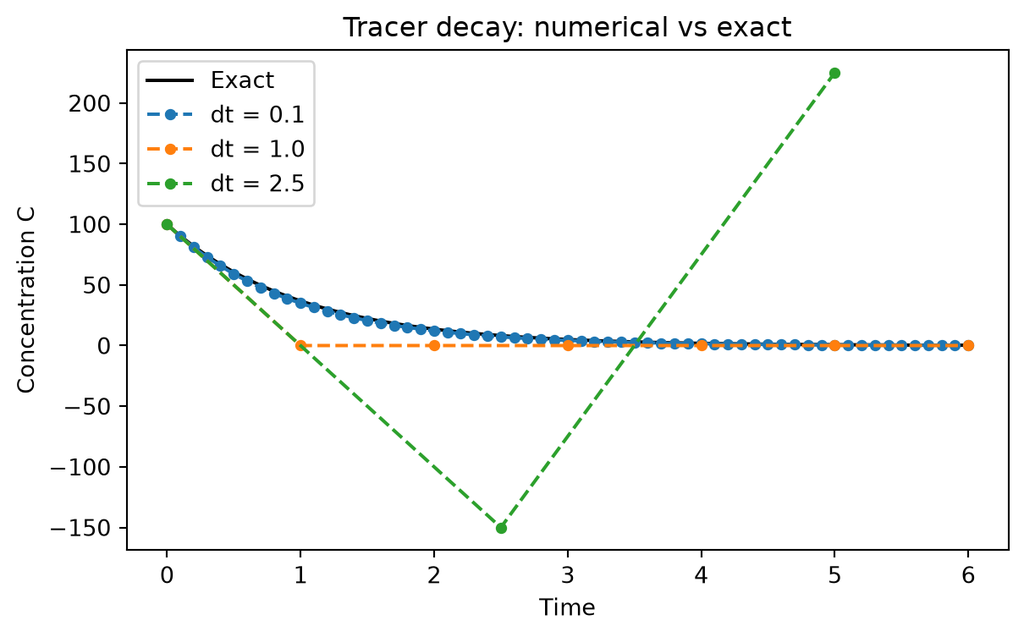

```python
def decay_numerical(C0, k, dt, t_end):
    """Return arrays of time and concentration for forward-Euler tracer decay."""
    n = int(t_end / dt)
    C = C0
    ts = [0.0]
    Cs = [C0]
    for i in range(n):
        C = C + (-k * C) * dt          # forward difference
        ts.append((i + 1) * dt)
        Cs.append(C)
    return np.array(ts), np.array(Cs)

# The exact answer, for comparison
C0, k, t_end = 100.0, 1.0, 6.0
t_fine = np.linspace(0, t_end, 200)
exact = C0 * np.exp(-k * t_fine)

fig, ax = plt.subplots(figsize=(7, 4))
ax.plot(t_fine, exact, "k-", label="Exact")

for dt in [0.1, 1.0, 2.5]:
    ts, Cs = decay_numerical(C0, k, dt, t_end)
    ax.plot(ts, Cs, "o--", markersize=4, label=f"dt = {dt}")

ax.set_xlabel("Time")
ax.set_ylabel("Concentration C")
ax.set_title("Tracer decay: numerical vs exact")
ax.legend()
plt.show()
```

With a small step the numerical solution sits on top of the exact curve. With a large step it drifts, and at `dt = 2.5` it oscillates wildly and goes negative — a physically impossible result. This is an example of **numerical instability**.

**Choosing a sensible time step is one of the most important practical skills in numerical modelling.**

## Boundary and initial conditions

The lecture stressed that to solve a differential equation you also need to specify conditions at the edges of the problem.

- When the independent variable is **time**, these are called **initial conditions** — the starting value, `C0` above.
- When it is **space**, they are called **boundary conditions** — for example, no flow through a solid wall, or a fixed concentration at an inflow.

Every model in this course begins by setting these conditions explicitly.

# Chapter 2.2 Process-based models: concept

## Example 1: A reservoir box model

```python
import numpy as np
import matplotlib.pyplot as plt

# ---- Parameters ----
V = 1.0e6        # lake volume (m^3)
Q = 5.0e3        # river inflow (m^3 per day)
C_in = 10.0      # incoming concentration (mg/L)
k = 0.05         # in-lake decay rate (per day)

# ---- Time settings ----
dt = 1.0         # time step (days)
days = 200

# ---- Initial condition ----
C = 0.0          # clean lake

# ---- Storage ----
history = [C]

# ---- Time loop ----
for _ in range(days):
    dCdt = (Q * C_in - Q * C - k * V * C) / V   # the rate of change
    C = C + dCdt * dt                            # forward difference
    history.append(C)

# ---- A quick look at the numbers ----
print(f"Started at {history[0]:.2f} mg/L")
print(f"After 10 days: {history[10]:.2f} mg/L")
print(f"After 50 days: {history[50]:.2f} mg/L")
print(f"After {days} days: {history[-1]:.2f} mg/L")
```

```
Started at 0.00 mg/L
After 10 days: 0.39 mg/L
After 50 days: 0.86 mg/L
After 200 days: 0.91 mg/L
```

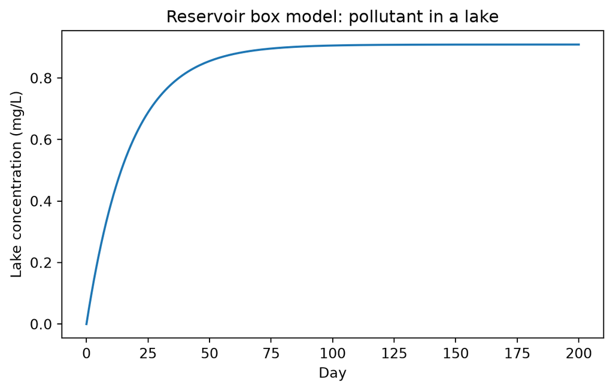

```python
fig, ax = plt.subplots(figsize=(7, 4))
ax.plot(history)
ax.set_xlabel("Day")
ax.set_ylabel("Lake concentration (mg/L)")
ax.set_title("Reservoir box model: pollutant in a lake")
plt.show()
```

The concentration rises from clean water and levels off at a **steady state**, where inflow balances outflow plus decay. Setting dC/dt = 0 gives the analytical steady state:

```python
C_star = (Q * C_in) / (Q + k * V)
print(f"Analytical steady state: {C_star:.2f} mg/L")
print(f"Numerical final value:   {history[-1]:.2f} mg/L")
print(f"Difference:              {abs(C_star - history[-1]):.4f} mg/L")
```

```
Analytical steady state: 0.91 mg/L
Numerical final value:   0.91 mg/L
Difference:              0.0000 mg/L
```

Whenever you can, check a numerical model against an analytical result like this — it catches mistakes early.

## Sweeping a parameter

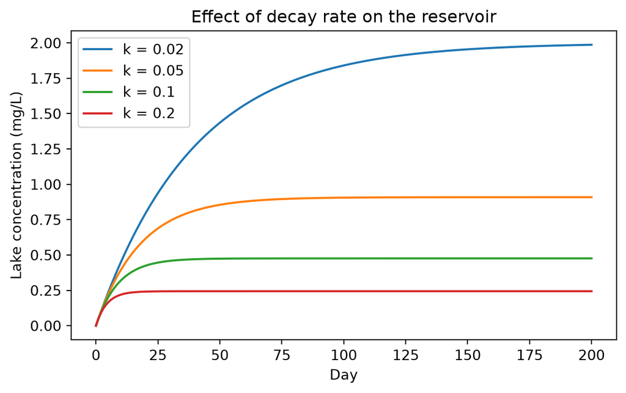

```python
fig, ax = plt.subplots(figsize=(7, 4))

for k_test in [0.02, 0.05, 0.10, 0.20]:
    C = 0.0
    history = [C]
    for _ in range(days):
        dCdt = (Q * C_in - Q * C - k_test * V * C) / V
        C = C + dCdt * dt
        history.append(C)
    ax.plot(history, label=f"k = {k_test}")

ax.set_xlabel("Day")
ax.set_ylabel("Lake concentration (mg/L)")
ax.set_title("Effect of decay rate on the reservoir")
ax.legend()
plt.show()
```

## Example 2: The estuary sediment box model

This is the lecture’s worked example. [formula etc. in the lecture notes]. The model is a single box representing the estuary, with sediment coming in and going out. The bed level rises or falls depending on whether more sediment comes in than goes out.

Rearrange for the change in bed level over one tidal period T :

```python
# ---- Inputs (illustrative; you will change these in the lab) ----
C_in  = 0.05      # incoming sediment concentration (kg/m^3)
C_out = 0.03      # outgoing sediment concentration (kg/m^3)
U_in  = 0.8       # incoming velocity (m/s)
U_out = 0.8       # outgoing velocity (m/s)
dx    = 5000.0    # estuary length (m)
T     = 12.4 * 3600   # tidal period (s)
eps   = 0.4       # porosity

# ---- Discretised mass balance, solved for dz ----
dz = (C_in * U_in - C_out * U_out) / (dx * (1 - eps)) * T

print(f"Bed level change over one tidal cycle: {dz*1000:.2f} mm")
print(f"Positive means infill, negative means erosion.")
```

```
Bed level change over one tidal cycle: 238.08 mm
Positive means infill, negative means erosion.
```

By changing the incoming and outgoing concentrations you can explore when an estuary traps sediment and when it flushes it out.

## Small Python drill: sweep the concentration difference

Try several values of `C_out` and print the result each time, without repeating your calculation code:

```python
def bed_change_mm(C_in, C_out, U_in, U_out, dx, T, eps):
    """Return the bed level change in millimetres over one tidal cycle."""
    dz = (C_in * U_in - C_out * U_out) / (dx * (1 - eps)) * T
    return dz * 1000

for C_out_test in [0.01, 0.02, 0.03, 0.04, 0.05, 0.06, 0.07]:
    dz_mm = bed_change_mm(0.05, C_out_test, 0.8, 0.8, 5000.0, 12.4*3600, 0.4)
    print(f"C_out = {C_out_test:.2f} kg/m^3  ->  dz = {dz_mm:+.2f} mm")
```

```
C_out = 0.01 kg/m^3  ->  dz = +476.16 mm
C_out = 0.02 kg/m^3  ->  dz = +357.12 mm
C_out = 0.03 kg/m^3  ->  dz = +238.08 mm
C_out = 0.04 kg/m^3  ->  dz = +119.04 mm
C_out = 0.05 kg/m^3  ->  dz = +0.00 mm
C_out = 0.06 kg/m^3  ->  dz = -119.04 mm
C_out = 0.07 kg/m^3  ->  dz = -238.08 mm
```

Notice the `:+.2f` — the `+` shows the sign explicitly so you can tell infilling from erosion at a glance.

## Example 3: The Lotka-Volterra predator-prey model

Both box models above tracked a s ingle state variable. Many environmental systems have several state variables tha tpush each other around. The classic example is a predator-prey system: rabbits and foxes.

**The story** In the 1920s Vito Volterra tried to explain a puzzle from the Adriatic Sea: during World War I, when fishing dropped sharply, the proportion of predatory fish in the catch went up. Around the same time Alfred Lotka arrived at the same pair of equations from chemical kinetics. The result — the Lotka-Volterra model — became one of the most famous models in ecology.

The insight is simple: more prey means more food for predators, so predators increase; but more predators eat more prey, so prey decrease; predators then run out of food and decrease too; with fewer predators, prey recover — and the cycle repeats.

A famous real-world echo of this pattern is the Hudson’s Bay Company lynx-and-hare fur records (1845 to 1935), which show hare and lynx peaks about a year or two apart with a cycle of roughly a decade.

**The equations** The lab notes give the equations. The Greek letters are rates you choose. Do not memorise the symbols — remember the logic: prey grow on their own but get eaten; predators grow from eating but die on their own.

### Building the model in Python

The workflow is the same as every model in Part 2: set up parameters, loop forward in time, plot. The only difference from a box model is that we update two state variables at each step instead of one.

```python
# ---- Parameters (the "knobs") ----
alpha = 1.1
beta  = 0.4
gamma = 0.4
delta = 0.1

# ---- Initial populations ----
x0 = 10.0
y0 = 10.0

# ---- Time settings — keep dt small ----
dt = 0.01
t_end = 100.0
n_steps = int(t_end / dt)

# ---- Pre-allocate the arrays (NumPy is faster than growing lists here) ----
time = np.zeros(n_steps + 1)    # note: +1 because we store the initial condition at step 0
prey = np.zeros(n_steps + 1)
pred = np.zeros(n_steps + 1)

# ---- Initial conditions ----
prey[0] = x0 # noteL: we store the initial condition at step 0
pred[0] = y0

# ---- Forward-Euler loop ----
for i in range(n_steps):
    x = prey[i]
    y = pred[i]
    dxdt = alpha * x - beta * x * y     # these follow the equations in labs notes
    dydt = delta * x * y - gamma * y    # these follow the equations in labs notes
    prey[i + 1] = x + dxdt * dt
    pred[i + 1] = y + dydt * dt
    time[i + 1] = (i + 1) * dt

# ---- Quick numerical summary ----
print(f"Simulation ran for {t_end} time units in {n_steps} steps of {dt}")
print(f"Prey  min = {prey.min():.2f}, max = {prey.max():.2f}, mean = {prey.mean():.2f}")
print(f"Pred  min = {pred.min():.2f}, max = {pred.max():.2f}, mean = {pred.mean():.2f}")
```

```
Simulation ran for 100.0 time units in 10000 steps of 0.01
Prey  min = 0.00, max = 36.28, mean = 3.72
Pred  min = 0.13, max = 12.97, mean = 2.86
```

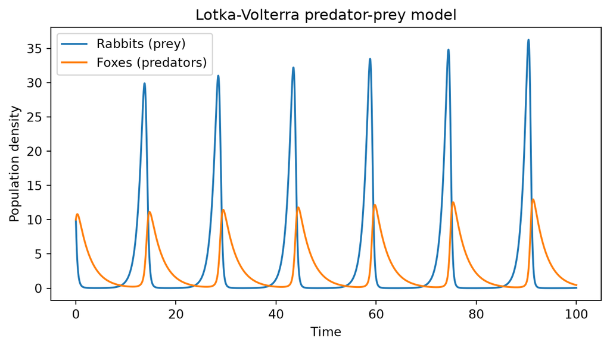

```python
# plot the results

fig, ax = plt.subplots(figsize=(8, 4))
ax.plot(time, prey, label="Rabbits (prey)")
ax.plot(time, pred, label="Foxes (predators)")
ax.set_xlabel("Time")
ax.set_ylabel("Population density")
ax.set_title("Lotka-Volterra predator-prey model")
ax.legend()
plt.show()
```

Both populations oscillate, with the fox curve trailing the rabbit curve — the same pattern seen in the lynx-hare data, produced from two simple equations.

### The phase-space plot

Instead of plotting both populations against time, plot rabbits on one axis and foxes on the other. Each point is a snapshot; as time moves forward, the point traces a loop.

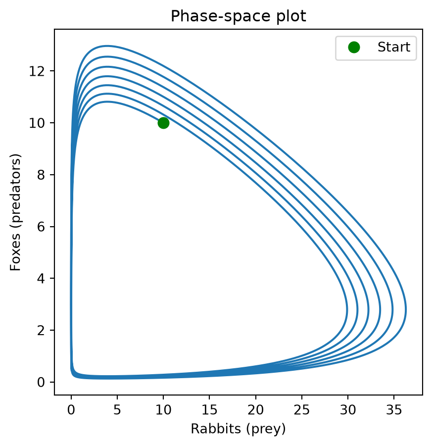

```python
fig, ax = plt.subplots(figsize=(5, 5))
ax.plot(prey, pred)                                             # prey on X, predator on Y
ax.plot(prey[0], pred[0], "go", markersize=8, label="Start")
ax.set_xlabel("Rabbits (prey)")
ax.set_ylabel("Foxes (predators)")
ax.set_title("Phase-space plot")
ax.legend()
plt.show()
```

In a perfect mathematical world this orbit would close exactly. If you see it spiralling outward, that is **numerical drift** from the Euler method — the same kind of error we saw with large time steps in Chapter 2.1.

### Small Python drill: mean over window

To compare model runs it is more useful to look at the mean population over the *last* portion of the run that a single final value. NumPy makes this a one-liner using slicing.

```python
final_window = int(50 / dt)   # last 50 time units at dt = 0.01

print(f"Total steps: {len(prey)}")
print(f"Last {final_window} steps ≈ last 50 time units")
print(f"Mean prey (last 50): {prey[-final_window:].mean():.2f}")
print(f"Mean pred (last 50): {pred[-final_window:].mean():.2f}")
```

```
Total steps: 10001
Last 5000 steps ≈ last 50 time units
Mean prey (last 50): 3.80
Mean pred (last 50): 2.66
```

The syntax `prey[-final_window:]` is “everything from `final_window` steps before the end”. You will use this exact pattern in the lab.

### Making the prey obey a carrying capacity

The classica model lets rabbits grow without limit in the absence of foxes. In reality, food, space, and disease put a ceiling on any population, called the **carrying capaity K**. Replace exponential growth with **logistic growth** by writing ax(1-x/K): [Formula in lab notes].

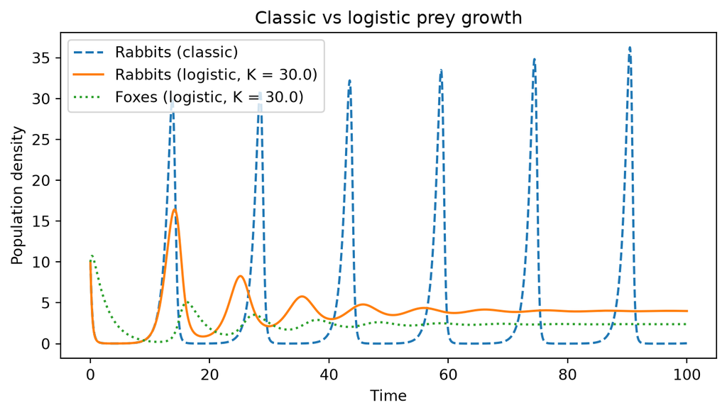

```python
# ---- Same set-up as before, plus a carrying capacity ----
K = 30.0
prey_L = np.zeros(n_steps + 1)
pred_L = np.zeros(n_steps + 1)
prey_L[0] = x0
pred_L[0] = y0

for i in range(n_steps):
    x = prey_L[i]
    y = pred_L[i]
    dxdt = alpha * x * (1 - x / K) - beta * x * y      # <-- the only change
    dydt = delta * x * y - gamma * y
    prey_L[i + 1] = x + dxdt * dt
    pred_L[i + 1] = y + dydt * dt

fig, ax = plt.subplots(figsize=(8, 4))
ax.plot(time, prey, label="Rabbits (classic)", linestyle="--")
ax.plot(time, prey_L, label=f"Rabbits (logistic, K = {K})")
ax.plot(time, pred_L, label=f"Foxes (logistic, K = {K})", linestyle=":")
ax.set_xlabel("Time")
ax.set_ylabel("Population density")
ax.set_title("Classic vs logistic prey growth")
ax.legend()
plt.show()
```

## What a process-based model shows

The three examples share the same shape (state variable, rate of change, loop, plot) but each shows something different:

- The **reservoir model** shows that a system with steady inputs approaches an equilibrium set by the balance of flows.
- The **estuary model** shows that a tiny difference between incoming and outgoing concentrations, multiplied by a full tidal cycle, adds up to a measurable bed-level change.
- The **Lotka-Volterra model** shows that oscillations can emerge from the coupling of two populations, without any external forcing.

That last point — **emergent behaviour from simple rules** — is a recurring theme in this course, and one we will see again when we move on to agent-based modelling in NetLogo.